# *Gradient Boosting - Supervised Machine Learning*

## *What is Gradient Boosting?*

*The term gradient boosting consists of two sub-terms, gradient and boosting. We already know that gradient boosting is a boosting technique.Let us see how the term ‘gradient’ is related here.*

*Gradient boosting re-defines boosting as a numerical optimisation problem where the objective is to minimise the loss function of the model by adding weak learners using gradient descent. Gradient descent is a first-order iterative optimisation algorithm for finding a local minimum of a differentiable function. As gradient boosting is based on minimising a loss function, different types of loss functions can be used resulting in a flexible technique that can be applied to regression, multi-class classification, etc.*

*Intuitively, gradient boosting is a stage-wise additive model that generates learners during the learning process (i.e., trees are added one at a time, and existing trees in the model are not changed). The contribution of the weak learner to the ensemble is based on the gradient descent optimisation process. The calculated contribution of each tree is based on minimising the overall error of the strong learner.*

*Gradient boosting does not modify the sample distribution as weak learners train on the remaining residual errors of a strong learner (i.e, pseudo-residuals). By training on the residuals of the model, this is an alternative means to give more importance to misclassified observations. Intuitively, new weak learners are being added to concentrate on the areas where the existing learners are performing poorly. The contribution of each weak learner to the final prediction is based on a gradient optimisation process to minimise the overall error of the strong learner.*

*Gradient boosting Algorithm involves three elements:*

- *A loss function to be optimized.*
- *Weak learner to make predictions.*
- *An additive model to add weak learners to minimize the loss function.*

### *Loss Function*

- *The loss function used depends on the type of problem being solved.*
- *It must be differentiable. Although, many standard loss functions are supported and you can define your own.*

### *Weak Learner*

- *We use decision trees as the weak learner in gradient boosting algorithm.*
- *Specifically, we use regression tree that output real values for splits. And whose output can be added together. It allows next models outputs to be added and “correct” the residuals in the predictions.*
- *Trees need to construct in a greedy manner. It helps in choosing the best split points based on purity scores like Gini or to cut the loss.*
- *Initially, such as in the case of AdaBoost. Also, we use very short decision trees that only had a single split, called a decision stump.*
- *Generally, we use larger trees with 4-to-8 levels.*
- *It is common to constrain the weak learners in specific ways. Such as a maximum number of layers, nodes, splits or leaf nodes.*
- *This is to ensure that the learners remain weak, but can still need to construct in a greedy manner.*

### *Additive Model*

- *Trees need to add one at a time, and existing trees in the model need not change.*
- *We use a gradient descent procedure to minimize the loss when adding trees.*
- *Traditionally, we use gradient tree to cut a set of parameters. Such as the coefficients in a regression equation or weights in a neural network. After calculating error or loss, the weights need to be update to minimize that error.*
- *Instead of parameters, we have weak learner sub-models or more specifically decision trees. After calculating the loss, to perform the gradient descent procedure. We must add a tree to the model that reduces the loss.*
- *We do this by parameterizing the tree. Then change the parameters of the tree and move in the right direction by reducing the residual loss.*

## *Understand Gradient Boosting Algorithm - Regression*

*Let’s consider a simple scenario in which we have several features, x1,x2,x3,x4 and try to predict y.*

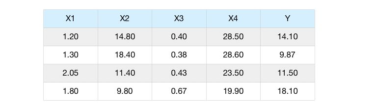

*Step 1* *: Make the first guess*

*The initial guess of the Gradient Boosting algorithm is to predict the average value of the target y. For example, if our features are the age x1 and the height x2 of a person… and we want to predict the weight of the person.*

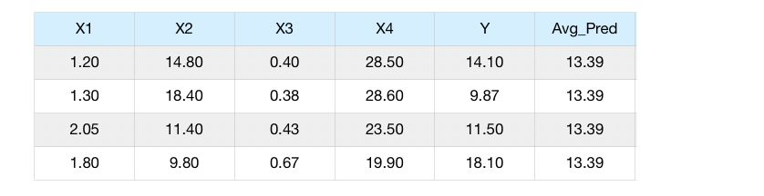

*Step 2* *: Compute the pseudo-residuals*

*For the variable x1, we compute the difference between the observations and the prediction we made. This is called the pseudo-residuals.*

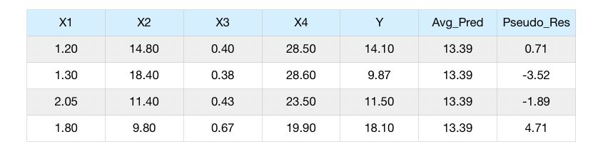

*We compute the pseudo-residuals for the first feature x1.*

*Step 3* *: Predict the pseudo-residuals*

*Then, we will be using the features x1,x2,x3,x4 to predict the pseudo-residuals column.*

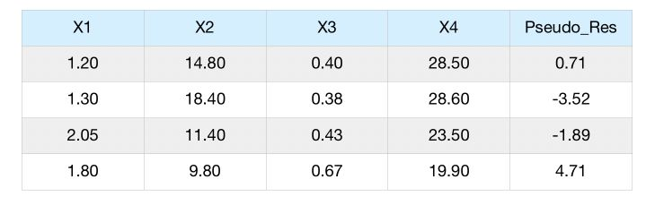

*We can now predict the pseudo-residuals using a tree, that typically has 8 to 32 leaves (so larger than a stump). By restricting the number of leaves of the tree we build, we obtain less leaves than residuals. Therefore, the outcome of a given branch of the tree is the average of the columns that lead to this leaf, as in a regression tree.*

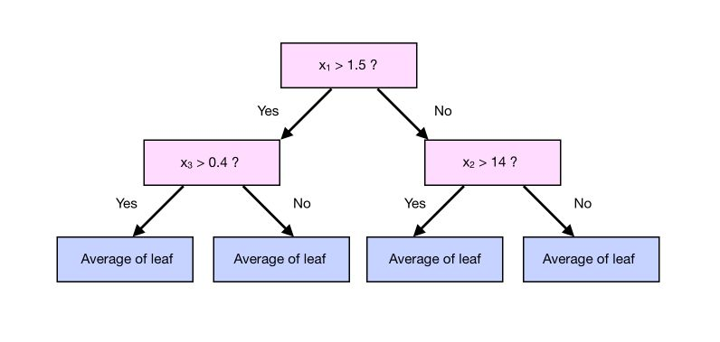

*Step 4* *: Make a prediction and compute the residuals*

*To make a prediction, we say that the average is 13.39. Then, we take our observation, run in through the tree, get the value of the leaf, and add it to 13.39.*

*If we stop here, we will most probably overfit. Gradient Boost applies a learning rate $lr$ to scale the contribution from a new tree, by applying a factor between 0 and 1.*

*The idea behind the learning rate is to make a small step in the right direction. This allows an overall lower variance.*

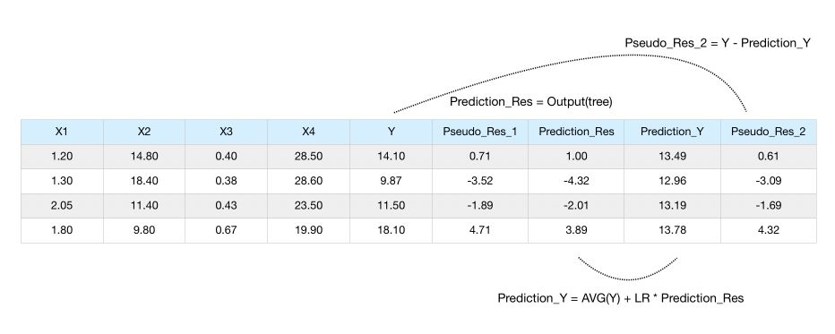

*Notice how all the residuals got smaller now.*

*Step 5* *: Make a second prediction*

*Now, we :*

- *build a second tree*
- *compute the prediction using this second tree*
- *compute the residuals according to the prediction*
- *build the third tree*
- *…*

_Let’s just cover how to compute the prediction. We are still using the features x1,x2,x3,x4 to predict the new residuals Pseudo_Res*2.*

*We build a tree to estimate those residuals. Once we have this tree (with a limited number of leaves), we are ready to make the new prediction :*

*The prediction is equal to :*

- *the average value initially computed*
- *plus LR * the predicted residuals at step 1*
- *plus LR * the predicted residuals at step 2*

*Notice how we always apply the same Learning Rate. We are now ready to compute the new residuals, fit the 3rd tree on it, compute the 4th residuals… and so on, until :*

- *we reach the maximum number of trees specified*
- *or we don’t learn significantly anymore*

```python
# Packages / libraries

import os #provides functions for interacting with the operating system

import numpy as np
import pandas as pd
from matplotlib import pyplot as plt
import seaborn as sns

%matplotlib inline
import math
from math import sqrt
import random
import time

import warnings
warnings.filterwarnings('ignore')
```

```python
from sklearn.preprocessing import LabelEncoder, StandardScaler
from sklearn.metrics import accuracy_score, f1_score, log_loss,mean_squared_error
from sklearn.model_selection import train_test_split, KFold, cross_val_score

from sklearn.ensemble import GradientBoostingClassifier
from sklearn.ensemble import GradientBoostingRegressor
```

## *Manual Implementation of Gradient Boosting Regression*

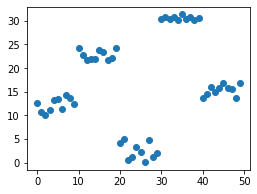

```python
x = np.arange(0,50)
x = pd.DataFrame({'x':x})

y1 = np.random.uniform(10,15,10)
y2 = np.random.uniform(20,25,10)
y3 = np.random.uniform(0,5,10)
y4 = np.random.uniform(30,32,10)
y5 = np.random.uniform(13,17,10)

y = np.concatenate((y1,y2,y3,y4,y5))
y = y[:,None]

plt.figure(figsize=(4,3))
plt.scatter(x,y)
plt.show()
```

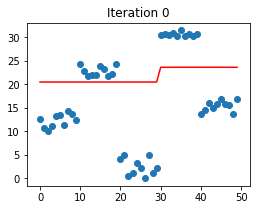

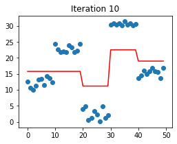

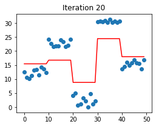

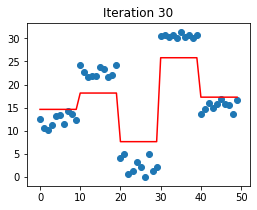

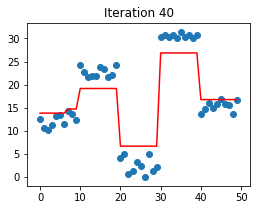

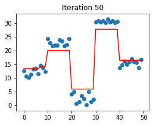

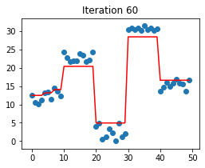

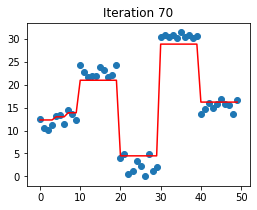

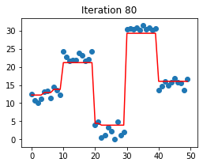

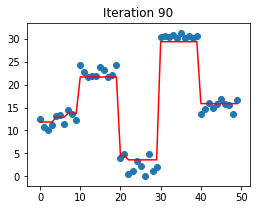

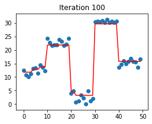

```python
from sklearn import tree

xi = x.copy()
yi = y.copy()

# Initialize error to 0
ei = 0
n = len(yi)

# Initialize predictions with average
predf = np.ones(n) * np.mean(yi)

lr = 0.3

# Iterate according to the number of iterations chosen
for i in range(101):

    # Step 2.a)
    # Fit the decision tree / stump (max_depth = 1) on xi, yi

    clf = tree.DecisionTreeRegressor(max_depth=1)
    model = clf.fit(xi, yi)

    # Use the fitted model to predict yi

    predi = model.predict(xi)

    # Step 2.c)
    # Compute the new prediction (learning rate !)
    # Compute the new residuals,
    # Set the new yi equal to the residuals

    predf = predf + lr * predi
    ei = y.reshape(-1,) - predf
    yi = ei

    # Every 10 iterations, plot the prediction vs the actual data
    if i % 10 == 0 :
        plt.figure(figsize=(4,3))
        plt.plot(x, predf, c='r')
        plt.scatter(x, y)
        plt.title("Iteration " + str(i))
        plt.show()
```

## *Understand Gradient Boosting Algorithm - Classification*

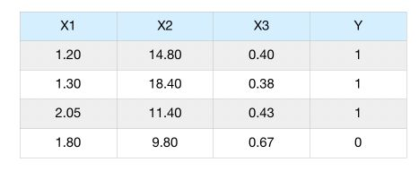

*Step 1* *: Make the first guess*

*The initial guess of the Gradient Boosting algorithm is to predict the log of the odds of the target y, the equivalent of the average for the logistic regression.*

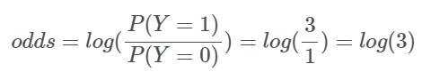

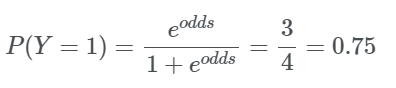

*If this probability is greater than 0.5, we classify as 1. Else, we classify as 0.*

*Step 2* *: Compute the pseudo-residuals*

*For the variable x1, we compute the difference between the observations and the prediction we made. This is called the pseudo-residuals.*

*We have now predicted a value for every sample, the same value for all of them. The next step is to compute the residuals :*

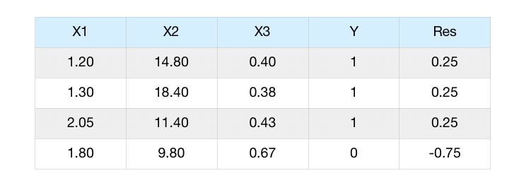

*Step 3* *: Predict the pseudo-residuals*

*As previously, we use the features 1 to 3 to predict the residuals. Suppose that we build the classification tree to predict the output value of the tree :*

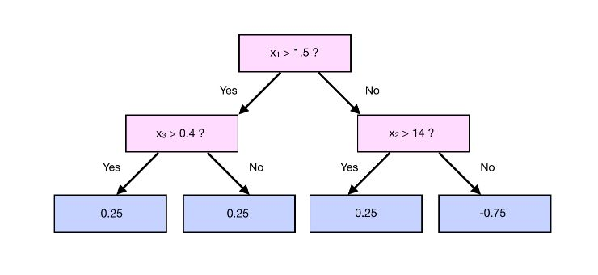

*In that case, we cannot use the output of a leaf (or the average output if we have more observations) as the predicted value, since we applied a transformation initiative.*

*We need to apply another transformation :*

*For example, take a case in which we have 1 more observation that falls into a leaf :*

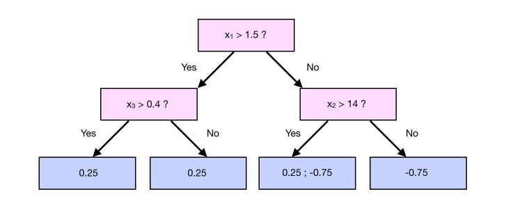

*In that case, the output value of the branch that contains 0.25 and -0.75 is :*

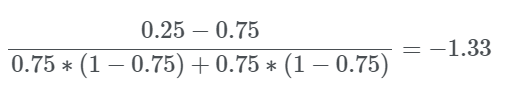

*Step 4* *: Make a prediction and compute the residuals*

*We can now compute the new prediction :*

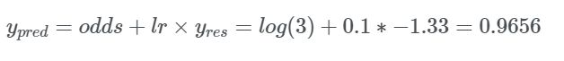

*We can now convert the new log odds prediction into a probability using the softmax function :*

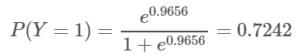

*The probability diminishes compared to before since we had 1 well classified and 1 incorrectly classified sample in this leaf.*

*Step 5* *: Make a second prediction*

*Now, we :*

- *build a second tree*
- *compute the prediction using this second tree*
- *compute the residuals according to the prediction*
- *build the third tree*
- *…*

*As before, we compute the prediction using :*

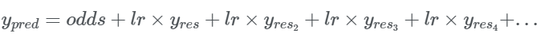

## *Classification Model*

```
GradientBoostingClassifier(*, loss='deviance', learning_rate=0.1, n_estimators=100, subsample=1.0, criterion='friedman_mse', min_samples_split=2, min_samples_leaf=1, min_weight_fraction_leaf=0.0, max_depth=3, min_impurity_decrease=0.0, min_impurity_split=None, init=None, random_state=None, max_features=None, verbose=0, max_leaf_nodes=None, warm_start=False, presort='deprecated', validation_fraction=0.1, n_iter_no_change=None, tol=0.0001, ccp_alpha=0.0)
```

```python
# Importing the dataset
training_data = pd.read_csv(r"C:\Users\PiyushSin\Desktop\datasets\titanic\train.csv")
testing_data = pd.read_csv(r"C:\Users\PiyushSin\Desktop\datasets\titanic\test.csv")
```

```python
# Drop the cabin column, as there are too many missing values
# Drop the ticket numbers too, as there are too many categories
# Drop names as they won't really help predict survivors

training_data.drop(labels=['Cabin', 'Ticket', 'Name'], axis=1, inplace=True)
testing_data.drop(labels=['Cabin', 'Ticket', 'Name'], axis=1, inplace=True)

# Taking the mean/average value would be impacted by the skew
# so we should use the median value to impute missing values

training_data["Age"].fillna(training_data["Age"].median(), inplace=True)
testing_data["Age"].fillna(testing_data["Age"].median(), inplace=True)
training_data["Embarked"].fillna("S", inplace=True)
testing_data["Fare"].fillna(testing_data["Fare"].median(), inplace=True)
```

```python
encoder_1 = LabelEncoder()
# Fit the encoder on the data
encoder_1.fit(training_data["Sex"])

# Transform and replace training data
training_sex_encoded = encoder_1.transform(training_data["Sex"])
training_data["Sex"] = training_sex_encoded
test_sex_encoded = encoder_1.transform(testing_data["Sex"])
testing_data["Sex"] = test_sex_encoded

encoder_2 = LabelEncoder()
encoder_2.fit(training_data["Embarked"])

training_embarked_encoded = encoder_2.transform(training_data["Embarked"])
training_data["Embarked"] = training_embarked_encoded
testing_embarked_encoded = encoder_2.transform(testing_data["Embarked"])
testing_data["Embarked"] = testing_embarked_encoded

# Any value we want to reshape needs be turned into array first
ages_train = np.array(training_data["Age"]).reshape(-1, 1)
fares_train = np.array(training_data["Fare"]).reshape(-1, 1)
ages_test = np.array(testing_data["Age"]).reshape(-1, 1)
fares_test = np.array(testing_data["Fare"]).reshape(-1, 1)

# Scaler takes arrays
scaler = StandardScaler()

training_data["Age"] = scaler.fit_transform(ages_train)
training_data["Fare"] = scaler.fit_transform(fares_train)
testing_data["Age"] = scaler.fit_transform(ages_test)
testing_data["Fare"] = scaler.fit_transform(fares_test)
```

```python
# Now to select our training/testing data
X_features = training_data.drop(labels=['PassengerId', 'Survived'], axis=1)
y_labels = training_data['Survived']

print(X_features.head(5))

# Make the train/test data from validation

X_train, X_test, y_train, y_test = train_test_split(X_features, y_labels, test_size=0.1, random_state=27)
```

```
   Pclass  Sex       Age  SibSp  Parch      Fare  Embarked
0       3    1 -0.565736      1      0 -0.502445         2
1       1    0  0.663861      1      0  0.786845         0
2       3    0 -0.258337      0      0 -0.488854         2
3       1    0  0.433312      1      0  0.420730         2
4       3    1  0.433312      0      0 -0.486337         2
```

```python
# model building

lr_list = [0.05, 0.075, 0.1, 0.25, 0.5, 0.75, 1]

for learning_rate in lr_list:
    gb_clf = GradientBoostingClassifier(n_estimators = 20, learning_rate = learning_rate, max_features = 2, max_depth = 2, random_state = 24)
    gb_clf.fit(X_train, y_train)

    print('Learning Rate: ', learning_rate)
    print('Accuracy Score (training): {0:.3f}'.format(gb_clf.score(X_train,y_train)))
    print('Accuracy Score (validation): {0:.3f}'.format(gb_clf.score(X_test, y_test)))
```

```
Learning Rate:  0.05
Accuracy Score (training): 0.797
Accuracy Score (validation): 0.800
Learning Rate:  0.075
Accuracy Score (training): 0.810
Accuracy Score (validation): 0.844
Learning Rate:  0.1
Accuracy Score (training): 0.821
Accuracy Score (validation): 0.833
Learning Rate:  0.25
Accuracy Score (training): 0.823
Accuracy Score (validation): 0.833
Learning Rate:  0.5
Accuracy Score (training): 0.829
Accuracy Score (validation): 0.867
Learning Rate:  0.75
Accuracy Score (training): 0.839
Accuracy Score (validation): 0.878
Learning Rate:  1
Accuracy Score (training): 0.854
Accuracy Score (validation): 0.867
```

```python
gb_clf2 = GradientBoostingClassifier(n_estimators = 20, learning_rate = 0.5, max_features = 2, max_depth = 2, random_state = 24)
gb_clf2.fit(X_train, y_train)
```

```
GradientBoostingClassifier(learning_rate=0.5, max_depth=2, max_features=2,
                           n_estimators=20, random_state=24)
```

```python
y_pred = gb_clf2.predict(X_test)
```

```python
# Making the Confusion Matrix
from sklearn.metrics import confusion_matrix

cm = confusion_matrix(y_test, y_pred)
cm
```

```
array([[49,  6],
       [ 6, 29]], dtype=int64)
```

```python
from sklearn.metrics import classification_report

print(classification_report(y_test, y_pred))
```

```
              precision    recall  f1-score   support

           0       0.89      0.89      0.89        55
           1       0.83      0.83      0.83        35

    accuracy                           0.87        90
   macro avg       0.86      0.86      0.86        90
weighted avg       0.87      0.87      0.87        90
```

```python
gb_clf2.feature_importances_
```

```
array([0.08509088, 0.60688092, 0.11120413, 0.05340955, 0.02587878,
       0.1144469 , 0.00308884])
```

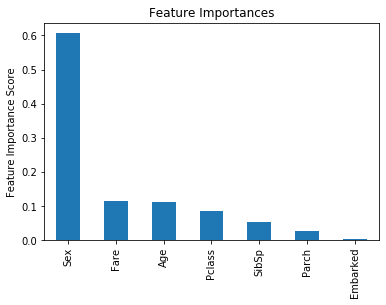

```python
feat_imp = pd.Series(gb_clf2.feature_importances_, X_train.columns).sort_values(ascending=False)
feat_imp.plot(kind='bar', title='Feature Importances')
plt.ylabel('Feature Importance Score')
```